# Is Your Degree Worth It?

Chase Rasmussen

2025-04

# Introduction

My project for this class is something we are all familiar with, the cost of schooling. Over the past five years, the cost of higher education in the sciences has continued to rise, leading many students to ask a critical question: Is the degree worth the debt? In this project, I explore that very question by analyzing and comparing tuition costs—essentially the debt accrued—against the average salaries of science degree holders at three academic levels: Bachelor’s, Master’s, and Doctorate.

Using a curated list of common science disciplines, from General Biology to Environmental Science, I intend to present a clear, visual comparison of what students are investing in their education versus what they can expect to earn in the job market. My goal is to provide prospective students, educators, and policymakers with an accessible tool that highlights both the financial challenges and potential returns of pursuing a science degree in today’s economy

## Data

My data set explores the relationship between average salaries and tuition costs for various biology-related fields across different degree levels (Bachelor’s, Master’s, and Doctorate) from 2020 to 2024. It includes specific disciplines such as General Biology, Marine Biology, Molecular Biology, Botany, Zoology, Genetics, Ecology, Microbiology, Biochemistry, and Environmental Science. By analyzing this data, you can identify trends in salary growth and tuition costs over time, and compare how these factors vary across different specializations and degree levels. This information can be valuable for students and professionals making educational and career decisions in the biological sciences. The data presented reflects estimated averages based on publicly available trends from sources such as the U.S. Bureau of Labor Statistics, the National Center for Education Statistics, and institutional reporting. Exact figures were interpolated for visualization and comparison purposes only. The sources are at the bottom of the page and the data was compiled by me.

```r
#libraries
library(readxl)
library(tidyverse)
library(scales)
library(kableExtra)
library(knitr)

# raw data pull
raw_data <- read_excel("Degree vs Income Data.xlsx")

kable((raw_data), caption = "Degree vs Income Data")
```

Degree vs Income Data

| Bachelors Degree | Average Salary in 2020 | Average Salary in 2021 | Average Salary in 2022 | Average Salary in 2023 | Average Salary in 2024 | Average Tuition cost 2020 | Average Tuition cost 2021 | Average Tuition cost 2022 | Average Tuition cost 2023 | Average Tuition cost 2024 |
| --- | --- | --- | --- | --- | --- | --- | --- | --- | --- | --- |
| General Biology | 50000 | 51000 | 52000 | 53000 | 54000 | 42000 | 44000 | 46000 | 48000 | 50000 |
| Marine Biology | 45000 | 46000 | 47000 | 48000 | 49000 | 42000 | 44000 | 46000 | 48000 | 50000 |
| Molecular Biology | 55000 | 56000 | 57000 | 58000 | 59000 | 42000 | 44000 | 46000 | 48000 | 50000 |
| Botany | 45000 | 41000 | 42000 | 43000 | 44000 | 42000 | 44000 | 46000 | 48000 | 50000 |
| Zoology | 45000 | 46000 | 47000 | 48000 | 49000 | 42000 | 44000 | 46000 | 48000 | 50000 |
| Genetics | 60000 | 61000 | 62000 | 63000 | 64000 | 42000 | 44000 | 46000 | 48000 | 50000 |
| Ecology | 50000 | 51000 | 52000 | 53000 | 54000 | 42000 | 44000 | 46000 | 48000 | 50000 |
| Microbiology | 55000 | 56000 | 57000 | 58000 | 59000 | 42000 | 44000 | 46000 | 48000 | 50000 |
| Biochemistry | 60000 | 61000 | 62000 | 63000 | 64000 | 42000 | 44000 | 46000 | 48000 | 50000 |
| Environmental Science | 50000 | 51000 | 52000 | 53000 | 54000 | 42000 | 44000 | 46000 | 48000 | 50000 |
| Masters Degree | NA | NA | NA | NA | NA | NA | NA | NA | NA | NA |
| General Biology | 67000 | 68000 | 69000 | 70000 | 71000 | 66000 | 69000 | 73000 | 75000 | 78000 |
| Marine Biology | 54000 | 55000 | 56000 | 57000 | 58000 | 66232 | 69000 | 72000 | 75000 | 78000 |
| Molecular Biology | 69000 | 70000 | 71000 | 72000 | 73000 | 66696 | 69600 | 72400 | 75200 | 78000 |
| Botany | 74000 | 75000 | 76000 | 77000 | 78000 | 68968 | 71600 | 74000 | 77000 | 80000 |
| Zoology | 60000 | 61000 | 62000 | 63000 | 64000 | 68382 | 71000 | 74000 | 77000 | 80000 |
| Genetics | 69000 | 70000 | 71000 | 72000 | 73000 | 68000 | 71000 | 74000 | 77000 | 80000 |
| Ecology | 61000 | 62000 | 63000 | 64000 | 65000 | 69230 | 72000 | 75000 | 78000 | 81000 |
| Microbiology | 73000 | 74000 | 75000 | 76000 | 77000 | 69086 | 72000 | 75000 | 78000 | 81000 |
| Biochemistry | 75000 | 76000 | 77000 | 78000 | 79000 | 67902 | 71000 | 74000 | 77000 | 80000 |
| Environmental Science | 71000 | 72000 | 73000 | 74000 | 75000 | 65290 | 68000 | 71000 | 74000 | 77000 |
| Doctorate Degree | NA | NA | NA | NA | NA | NA | NA | NA | NA | NA |
| General Biology | 99000 | 100000 | 101000 | 102000 | 103000 | 89654 | 93000 | 97400 | 99800 | 103200 |
| Marine Biology | 70000 | 71000 | 72000 | 73000 | 74000 | 90464 | 94000 | 98000 | 102000 | 106000 |
| Molecular Biology | 95000 | 96000 | 97000 | 98000 | 99000 | 91392 | 95200 | 98800 | 102400 | 106000 |
| Botany | 97000 | 98000 | 99000 | 100000 | 101000 | 95936 | 99200 | 102000 | 106000 | 110000 |
| Zoology | 81000 | 82000 | 83000 | 84000 | 85000 | 94284 | 97400 | 101000 | 105000 | 109000 |
| Genetics | 84000 | 85000 | 86000 | 87000 | 88000 | 94000 | 98000 | 102000 | 106000 | 110000 |
| Ecology | 92000 | 93000 | 94000 | 95000 | 96000 | 96460 | 100000 | 104000 | 108000 | 112000 |
| Microbiology | 114000 | 115000 | 116000 | 117000 | 118000 | 96172 | 100000 | 104000 | 108000 | 112000 |
| Biochemistry | 107000 | 108000 | 109000 | 110000 | 111000 | 93804 | 99000 | 102000 | 106000 | 110000 |
| Environmental Science | 80000 | 81000 | 82000 | 83000 | 84000 | 88580 | 92000 | 96000 | 100000 | 104000 |

The original data was not in a format that RStudio could easily interpret for analysis or visualization. To begin, I identified and separated the rows corresponding to Bachelor’s, Master’s, and Doctorate degrees. This allowed me to split the dataset into three distinct subsets based on degree level.

I then used mutate() to tag each subset with its respective degree level and created separate data frames for each. After that, I recombined these into a single, unified dataset using bind_rows(), ensuring each entry was clearly labeled by degree level. To improve clarity, I repositioned the DegreeLevel column so it appeared before the Discipline column.

To prepare the data for plotting, I used pivot_longer() to convert the salary and tuition columns from wide to long format. This created a tidy structure where each row represents a single year, with associated discipline, salary (or tuition), and degree level.

Finally, I grouped the data by discipline, allowing for meaningful comparisons across years and degree levels. The result was clean and structured but I felt like it was still too dense to really identify the significance of it.

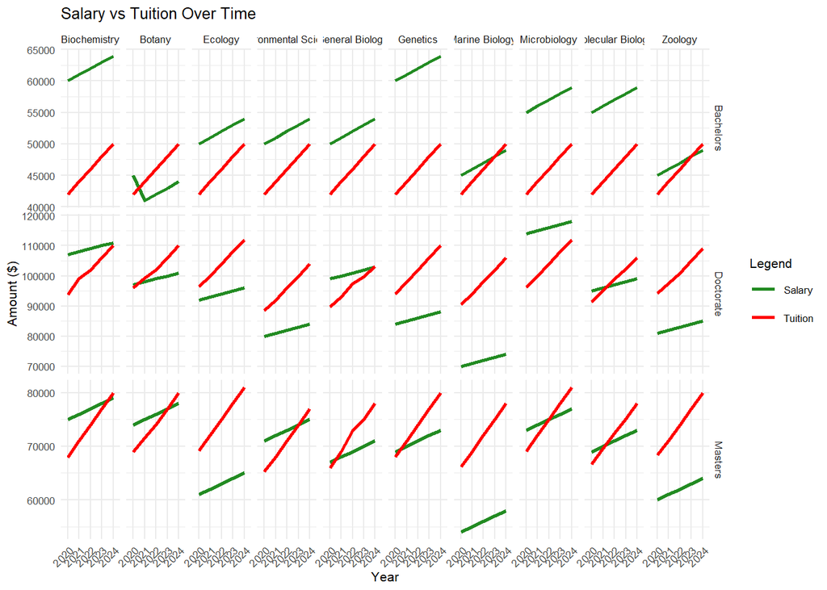

```r
# Identify where each section begins
masters_start <- which(raw_data$`Bachelors Degree` == "Masters Degree")
doctorate_start <- which(raw_data$`Bachelors Degree` == "Doctorate Degree")

# Split data into 3 sections
bachelors_data <- raw_data[1:(masters_start - 1), ] %>%
  mutate(DegreeLevel = "Bachelors")

masters_data <- raw_data[(masters_start + 1):(doctorate_start - 1), ] %>%
  mutate(DegreeLevel = "Masters")

doctorate_data <- raw_data[(doctorate_start + 1):nrow(raw_data), ] %>%
  mutate(DegreeLevel = "Doctorate")
# Combine all into one clean dataframe
clean_data <- bind_rows(bachelors_data, masters_data, doctorate_data) %>%
  rename(Discipline = `Bachelors Degree`)


# Optional: reorder columns
clean_data <- clean_data %>%
  relocate(DegreeLevel, .before = Discipline)
#now convert to long format for plotting
# Make salary long
salary_long <- clean_data %>%
  pivot_longer(
    cols = starts_with("Average Salary"),
    names_to = "Year",
    values_to = "Salary"
  ) %>%
  mutate(Year = str_extract(Year, "\\d+"))
# Make tuition long
tuition_long <- clean_data %>%
  pivot_longer(
    cols = starts_with("Average Tuition"),
    names_to = "Year",
    values_to = "Tuition"
  ) %>%
  mutate(Year = str_extract(Year, "\\d+"))

tidy_data <- left_join(salary_long, tuition_long,
                       by = c("DegreeLevel", "Discipline", "Year"))

ggplot(tidy_data, aes(x = Year, group = interaction(DegreeLevel, Discipline))) +
  geom_line(aes(y = Salary, color = "Salary"), size = 1) +
  geom_line(aes(y = Tuition, color = "Tuition"), size = 1) +
  facet_grid(DegreeLevel ~ Discipline, scales = "free_y") +
  scale_color_manual(values = c("Salary" = "forestgreen", "Tuition" = "red")) +
  labs(title = "Salary vs Tuition Over Time",
       x = "Year", y = "Amount ($)", color = "Legend") +
  theme_minimal(base_size = 8) +
  theme(axis.text.x = element_text(angle = 45, hjust = 1))
```

Science degree tuition cost and average salary, it is still hard to evaluate the data after a few different techniques to try to clean it up. Now, I want to separate it all to dive into it. For all the main degree data, I just plotted each separated data set into a graph highlighting Year and Discipline with Salary and Tuition plotted.

# Bachelor’s Degree Data

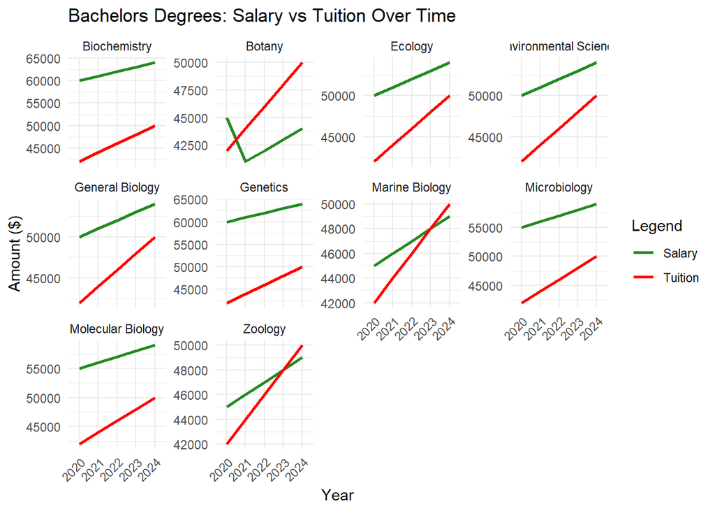

```r
#split the degree levels
# Split data into three degree levels
bachelors_data <- tidy_data %>% filter(DegreeLevel == "Bachelors")
masters_data   <- tidy_data %>% filter(DegreeLevel == "Masters")
doctorate_data <- tidy_data %>% filter(DegreeLevel == "Doctorate")

# bachelors plot
ggplot(bachelors_data, aes(x = Year, group = Discipline)) +
  geom_line(aes(y = Salary, color = "Salary"), size = 1) +
  geom_line(aes(y = Tuition, color = "Tuition"), size = 1) +
  facet_wrap(~Discipline, scales = "free_y") +
  scale_color_manual(values = c("Salary" = "forestgreen", "Tuition" = "red")) +
  labs(title = "Bachelors Degrees: Salary vs Tuition Over Time",
       x = "Year", y = "Amount ($)", color = "Legend") +
  theme_minimal() +
  theme(axis.text.x = element_text(angle = 45, hjust = 1))
```

Using just Bachelor’s degrees, lets dig into it to find out which degree at this level would be the best “return per dollar spent!” To do this, I will focus in just on 2024’s data. I used dplyr to filter, mutate, and arrange with a rank system. In my mutate, I assigned it ROI for Salary divided by Tuition. Then I used ggplot to make the following:

## Bachelors Degree 2024

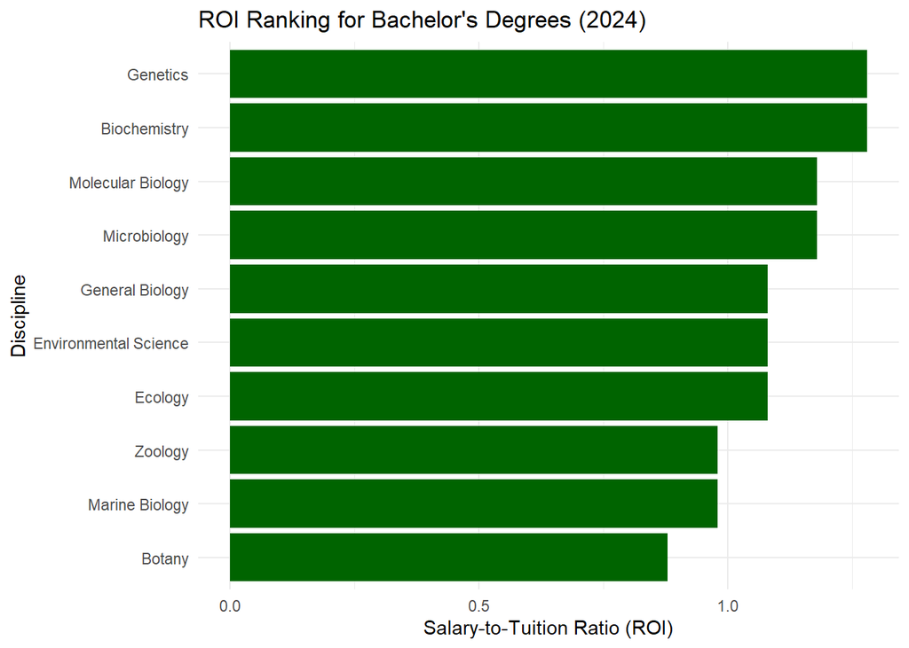

```r
# Filter for 2024 data
bachelors_2024 <- bachelors_data %>%
  filter(Year == "2024") %>%
  mutate(
    ROI = Salary / Tuition
  ) %>%
  arrange(desc(ROI)) %>%
  mutate(Rank = row_number())

ggplot(bachelors_2024, aes(x = reorder(Discipline, ROI), y = ROI)) +
  geom_col(fill = "darkgreen") +
  coord_flip() +
  labs(title = "ROI Ranking for Bachelor's Degrees (2024)",
       x = "Discipline",
       y = "Salary-to-Tuition Ratio (ROI)") +
  theme_minimal()
```

If you were to take a real world application suggesting ~75% of gross income is netted, and with other financial obligations paying heafty approximation of that money toward your tuition, it would look like this:

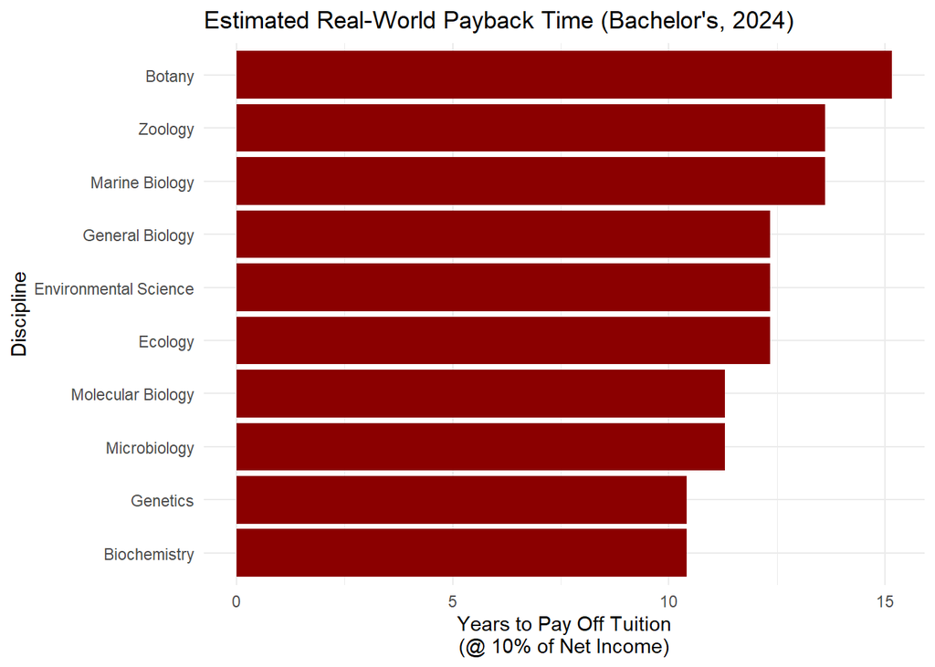

```r
bachelors_real_world <- bachelors_data %>%
  filter(Year == "2024") %>%
  mutate(
    NetIncome = Salary * 0.75,
    AnnualLoanPayment = NetIncome * 0.10,
    RealWorldPaybackYears = Tuition / AnnualLoanPayment
  ) %>%
  arrange(RealWorldPaybackYears) %>%
  mutate(Rank = row_number()) %>%
  select(Rank, Discipline, Salary, Tuition, RealWorldPaybackYears)

ggplot(bachelors_real_world, aes(x = reorder(Discipline, RealWorldPaybackYears), y = RealWorldPaybackYears)) +
  geom_col(fill = "darkred") +
  coord_flip() +
  labs(title = "Estimated Real-World Payback Time (Bachelor's, 2024)",
       x = "Discipline",
       y = "Years to Pay Off Tuition\n(@ 10% of Net Income)") +
  theme_minimal()
```

## Bachelors finalized

In order from greatest ROI to least ROI :

```r
knitr::kable(bachelors_real_world, digits = 1,
             caption = "Estimated Payback Time (Real World) – Bachelor's Degrees (2024)")
```

Estimated Payback Time (Real World) – Bachelor’s Degrees (2024)

| Rank | Discipline | Salary | Tuition | RealWorldPaybackYears |
| --- | --- | --- | --- | --- |
| 1 | Genetics | 64000 | 50000 | 10.4 |
| 2 | Biochemistry | 64000 | 50000 | 10.4 |
| 3 | Molecular Biology | 59000 | 50000 | 11.3 |
| 4 | Microbiology | 59000 | 50000 | 11.3 |
| 5 | General Biology | 54000 | 50000 | 12.3 |
| 6 | Ecology | 54000 | 50000 | 12.3 |
| 7 | Environmental Science | 54000 | 50000 | 12.3 |
| 8 | Marine Biology | 49000 | 50000 | 13.6 |
| 9 | Zoology | 49000 | 50000 | 13.6 |
| 10 | Botany | 44000 | 50000 | 15.2 |

# Master’s Degree Data

I then repeated the same process I used on the bachelor’s data on the master’s data.

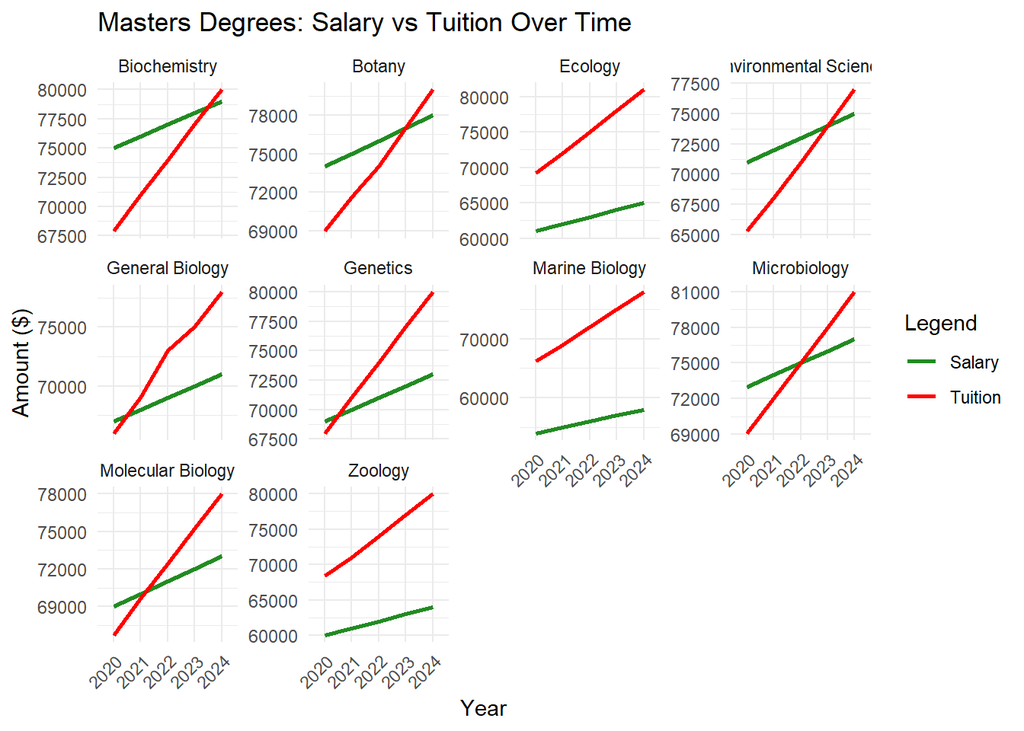

Using just Master’s degrees, lets find out which degree at this level would be the best “return per dollar spent!” To do this, I will focus in just on 2024’s data. I used dplyr to filter, mutate, and arrange with a rank system. In my mutate, I assigned it ROI for Salary divided by Tuition. Then I used ggplot to make the following:

## Master’s Degree 2024

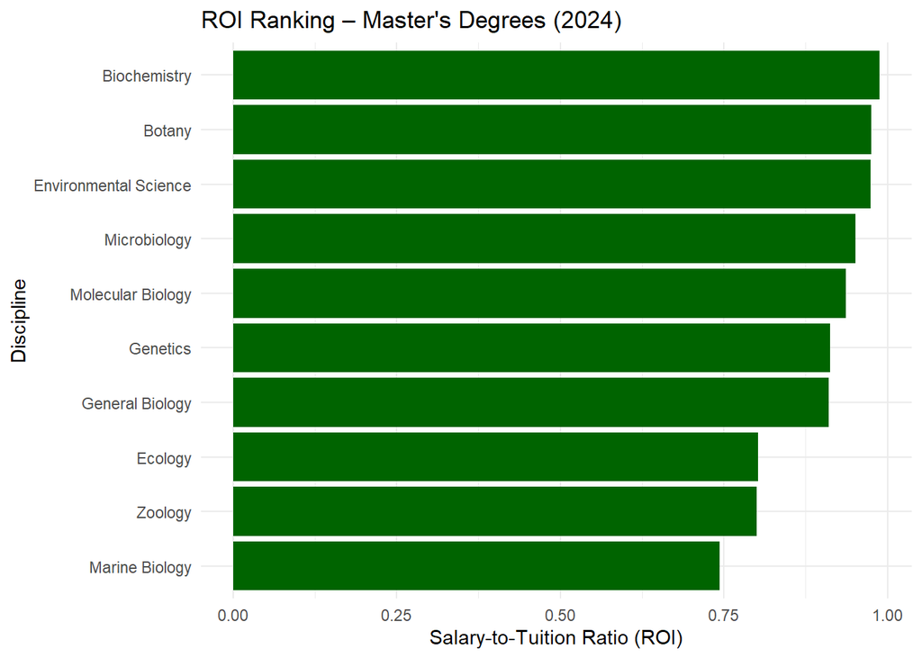

Now, with the same formula of a “Real-World” payback simulation.

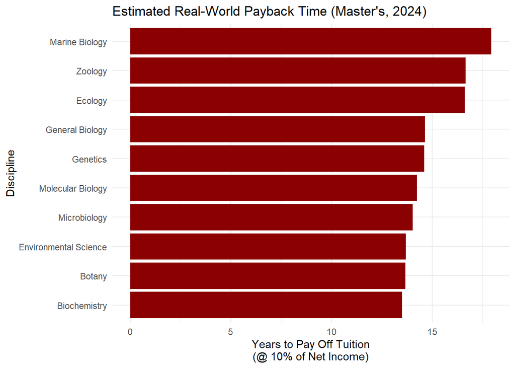

## Masters finalized

In order from greatest ROI to least ROI :

Estimated Payback Time (Real World) – Master’s Degrees (2024)

| Rank | Discipline | Salary | Tuition | RealWorldPaybackYears |
| --- | --- | --- | --- | --- |
| 1 | Biochemistry | 79000 | 80000 | 13.5 |
| 2 | Botany | 78000 | 80000 | 13.7 |
| 3 | Environmental Science | 75000 | 77000 | 13.7 |
| 4 | Microbiology | 77000 | 81000 | 14.0 |
| 5 | Molecular Biology | 73000 | 78000 | 14.2 |
| 6 | Genetics | 73000 | 80000 | 14.6 |
| 7 | General Biology | 71000 | 78000 | 14.6 |
| 8 | Ecology | 65000 | 81000 | 16.6 |
| 9 | Zoology | 64000 | 80000 | 16.7 |
| 10 | Marine Biology | 58000 | 78000 | 17.9 |

# Doctorate Degree Data

I then repeated the same process I used again on the doctorate data

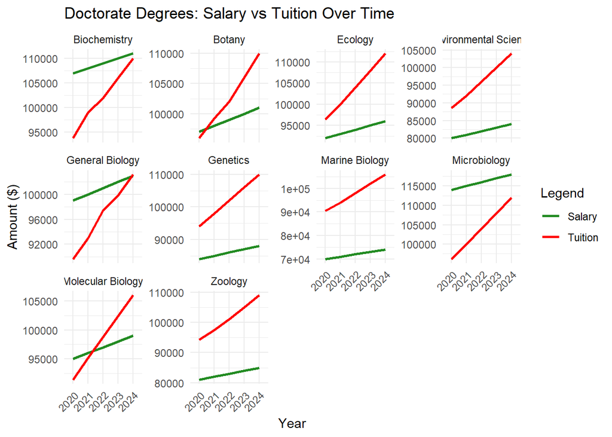

Using just doctorate degrees, lets find out which degree at this level would be the best “return per dollar spent!” To do this, I will focus in just on 2024’s data. I used dplyr to filter, mutate, and arrange with a rank system. In my mutate, I assigned it ROI for Salary divided by Tuition. Then I used ggplot to make the following:

## Doctorate Degree 2024

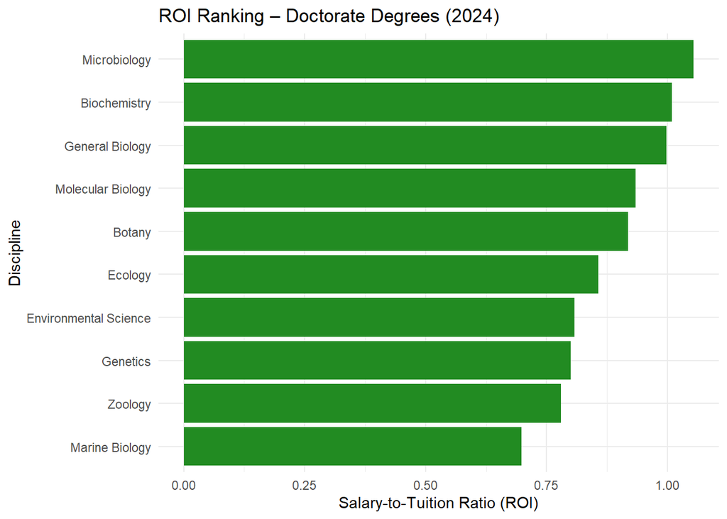

Now, with the same formula of a “Real-World” payback simulation.

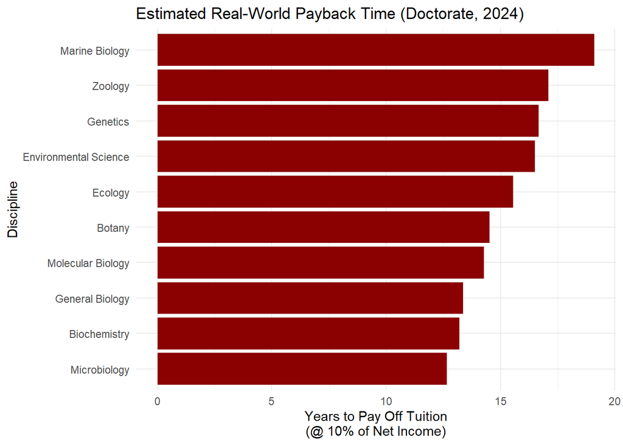

## Doctorate finalized

In order from greatest ROI to least ROI :

Estimated Payback Time (Real World) – Doctorate Degrees (2024)

| Rank | Discipline | Salary | Tuition | RealWorldPaybackYears |
| --- | --- | --- | --- | --- |
| 1 | Microbiology | 118000 | 112000 | 12.7 |
| 2 | Biochemistry | 111000 | 110000 | 13.2 |
| 3 | General Biology | 103000 | 103200 | 13.4 |
| 4 | Molecular Biology | 99000 | 106000 | 14.3 |
| 5 | Botany | 101000 | 110000 | 14.5 |
| 6 | Ecology | 96000 | 112000 | 15.6 |
| 7 | Environmental Science | 84000 | 104000 | 16.5 |
| 8 | Genetics | 88000 | 110000 | 16.7 |
| 9 | Zoology | 85000 | 109000 | 17.1 |
| 10 | Marine Biology | 74000 | 106000 | 19.1 |

# Summary

I then took a summary of all the data and combined the top 75% salary from all three degree levels with the “Real world payback” included. I then sliced the data and mutated it to only show the top 3 and bottom 3 disciplines at the degree level for those earnings. I used Knitr to report it.

```r
# Combine all degree levels and calculate real-world payback
combined_2024 <- bind_rows(bachelors_data, masters_data, doctorate_data) %>%
  filter(Year == "2024") %>%
  mutate(
    NetIncome = Salary * 0.75,
    AnnualLoanPayment = NetIncome * 0.10,
    RealWorldPaybackYears = Tuition / AnnualLoanPayment
  )

# Add a flag to mark top or bottom 3
top_and_bottom3 <- combined_2024 %>%
  arrange(RealWorldPaybackYears) %>%
  slice(c(1:3, (n() - 2):n())) %>%
  mutate(Position = case_when(
    row_number() <= 3 ~ "top",
    TRUE ~ "bottom"
  )) %>%
  select(Position, DegreeLevel, Discipline, Salary, Tuition, RealWorldPaybackYears)

# Build styled table
top_and_bottom3 %>%
  mutate(Discipline = ifelse(
    Position == "top",
    cell_spec(Discipline, underline = TRUE, color = "darkgreen"),
    cell_spec(Discipline, underline = TRUE, color = "darkred")
  )) %>%
  select(-Position) %>%
  kable(format = "html", escape = FALSE, digits = 1,
        caption = "Top & Bottom 3 Disciplines by Real-World Payback Time – All Degree Levels (2024)") %>%
  kable_styling(full_width = FALSE, bootstrap_options = c("striped", "hover", "condensed"))
```

Top & Bottom 3 Disciplines by Real-World Payback Time – All Degree Levels (2024)

| DegreeLevel | Discipline | Salary | Tuition | RealWorldPaybackYears |
| --- | --- | --- | --- | --- |
| Bachelors | Genetics | 64000 | 50000 | 10.4 |
| Bachelors | Biochemistry | 64000 | 50000 | 10.4 |
| Bachelors | Molecular Biology | 59000 | 50000 | 11.3 |
| Doctorate | Zoology | 85000 | 109000 | 17.1 |
| Masters | Marine Biology | 58000 | 78000 | 17.9 |
| Doctorate | Marine Biology | 74000 | 106000 | 19.1 |

This project explored the financial dynamics of higher education in the biological sciences by analyzing the relationship between tuition costs and average post-degree salaries from 2020 to 2024. Using curated data across Bachelor’s, Master’s, and Doctorate levels, I calculated both raw return-on-investment (ROI) and a more realistic “real-world” payback time, which factors in net income and responsible debt repayment. Visualizations included line charts tracking trends over time and bar charts ranking disciplines by their financial return. Among all degrees, Genetics (Bachelor’s), Biochemistry (Master’s), and Microbiology (Doctorate) emerged as the top performers in terms of efficient debt repayment, while other fields showed longer or less efficient financial outcomes. These findings highlight how discipline and degree level significantly impact the economic value of an education in the sciences.

# Conclusion

While passion and academic interest are important, the financial implications of pursuing a science degree can’t be ignored. This analysis reveals that not all degrees offer equal economic return, and students may benefit from aligning their interests with disciplines that also provide favorable payback outcomes. The “real-world” model—accounting for taxes and modest loan repayment behavior—provides a clearer, more practical view of the investment in education. As tuition continues to rise, such data-driven insights are essential for helping students make informed decisions about their academic and financial futures.

# Sources

```r
# Sources:  Tuition: https://nces.ed.gov/fastfacts/display.asp?id=76
#   Board Pricing:  https://research.collegeboard.org/trends/college-pricing
#   Salary: https://www.bls.gov/ooh/
#   Payscale calculation: https://www.payscale.com/research/US/Degree=Bachelor_of_Science_(BS)%2C_Biology/Salary
```